# Decoding Red and White Wine Quality

Franco Reinaldo Bonifacini (41540A)

December, 2023

## Abstract

This project aims to assess wine quality based on different variables that are involved during the production. The study distinguishes between red and white wines, investigating the positive and negative influences of specific factors on their quality. To accomplish this, the skills and tools acquired from the R coding course will be involved.

The primary goal will be to verify **that red wines demonstrate superior qualities when characterized by higher acidity, while white wines are better when possessing lower acidity levels and a sweeter taste profile**. In light of these, the attributes that affect positively a high-quality wine will be determined for both types: red and white wines.

```
Keywords: wine, quality, variables, attributes, acidity, sugar, pH.
```

## Introduction

Wine has an ancient origin, dating back to at least 5,400 B.C. Since then, and up to the present day, the consumer’s palate has continually refined, prioritizing the quality of wine. In today’s highly fragmented wine market, comprising both large companies and small family wineries, consumers have a diverse range of options. It is widely understood that the quality of the wine depends entirely on its production.

The quality is not determined until the final product is tasted. A significant challenge arises when a bottle of wine is produced, but if it fails to meet the expected superior quality, this often results in the waste of high-quality raw materials.

Considering these factors, this project aims to analyze and understand how variables influence the final quality of wine. It seeks to identify crucial attributes to consider during production in order to correct any deviations. Ultimately, the hypotheses stated in the abstract will be compared with the results of this project.

## Data Used

To execute this project, a dataset *(Kaggle, 2018)* containing values of various wine attributes was downloaded and linked to a variable named **wine_dataset**.

```r
wine_dataset <- read.csv('C:\\Users\\franc\\Documents\\GitHub\\rproject\\Dataset\\winequality.csv')
```

While a multitude of wine varieties exists in the market, in this case, they are divided between red wines and white wines. Both types are represented in this dataset and provides a sufficient amount of information to carry out the project.

```r
dim(wine_dataset)
```

```
## [1] 6497   13
```

These inputs include information about:

1. **Type:** red or white.
2. **Fixed acidity:** influences taste, pH, and overall wine life.
3. **Volatile acidity:** refers to steam-distillable acids.
4. **Citric acid:** provides a certain freshness to the wine.
5. **Residual sugar:** the amount of sugar that could not be fermented.
6. **Chlorides:** mineral salts in the wine.
7. **Free sulfur dioxide:** a powerful antimicrobial agent.
8. **Total sulfur dioxide:** used as a preservative, antioxidant, and antiseptic.
9. **Density:** also known as “specific gravity,” an analytical parameter of wine.
10. **pH:** a measure of acidity or alkalinity in an aqueous solution.
11. **Sulphates:** another preservative, antimicrobial, and antioxidant.
12. **Alcohol:** being wine a fermented beverage, it has an alcohol content.
13. **Quality:** a rating reflecting the overall quality of the wine.

```r
names(wine_dataset)
```

```
##  [1] "type"                 "fixed.acidity"        "volatile.acidity"
##  [4] "citric.acid"          "residual.sugar"       "chlorides"
##  [7] "free.sulfur.dioxide"  "total.sulfur.dioxide" "density"
## [10] "pH"                   "sulphates"            "alcohol"
## [13] "quality"
```

```r
head(wine_dataset)
```

```
##    type fixed.acidity volatile.acidity citric.acid residual.sugar chlorides
## 1 white           7.0             0.27        0.36           20.7     0.045
## 2 white           6.3             0.30        0.34            1.6     0.049
## 3 white           8.1             0.28        0.40            6.9     0.050
## 4 white           7.2             0.23        0.32            8.5     0.058
## 5 white           7.2             0.23        0.32            8.5     0.058
## 6 white           8.1             0.28        0.40            6.9     0.050
##   free.sulfur.dioxide total.sulfur.dioxide density   pH sulphates alcohol
## 1                  45                  170  1.0010 3.00      0.45     8.8
## 2                  14                  132  0.9940 3.30      0.49     9.5
## 3                  30                   97  0.9951 3.26      0.44    10.1
## 4                  47                  186  0.9956 3.19      0.40     9.9
## 5                  47                  186  0.9956 3.19      0.40     9.9
## 6                  30                   97  0.9951 3.26      0.44    10.1
##   quality
## 1       6
## 2       6
## 3       6
## 4       6
## 5       6
## 6       6
```

```r
tail(wine_dataset)
```

```
##      type fixed.acidity volatile.acidity citric.acid residual.sugar chlorides
## 6492  red           6.8            0.620        0.08            1.9     0.068
## 6493  red           6.2            0.600        0.08            2.0     0.090
## 6494  red           5.9            0.550        0.10            2.2     0.062
## 6495  red           6.3            0.510        0.13            2.3     0.076
## 6496  red           5.9            0.645        0.12            2.0     0.075
## 6497  red           6.0            0.310        0.47            3.6     0.067
##      free.sulfur.dioxide total.sulfur.dioxide density   pH sulphates alcohol
## 6492                  28                   38 0.99651 3.42      0.82     9.5
## 6493                  32                   44 0.99490 3.45      0.58    10.5
## 6494                  39                   51 0.99512 3.52        NA    11.2
## 6495                  29                   40 0.99574 3.42      0.75    11.0
## 6496                  32                   44 0.99547 3.57      0.71    10.2
## 6497                  18                   42 0.99549 3.39      0.66    11.0
##      quality
## 6492       6
## 6493       5
## 6494       6
## 6495       6
## 6496       5
## 6497       6
```

### Exploratory Data Analysis

Before analyzing the hypothesis and attributes, a check on the data structure was conducted to prevent potential errors in the future. This involved examining both data types and null values. To facilitate this and subsequent analyses in the project, the following packages were used:

```r
library(tidyverse)
library(ggplot2) # From the tidyverse collection (added to explicitly show its inclusion)
library(tibble) # From the tidyverse collection (added to explicitly show its inclusion)
library(dplyr) # From the tidyverse collection (added to explicitly show its inclusion)
library(gridExtra) # To visualize more than one plot together
library(grid) # To visualize more than one plot together
library(reshape2) # For data transformation
```

The ‘type’ column contains string values (character = chr), whereas the other columns consist of integer values (‘quality’ column) and numeric values (in the remaining columns). This indicates that no further corrections were needed regarding data types, facilitating calculations and data manipulation.

```r
str(wine_dataset)
```

```
## 'data.frame':    6497 obs. of  13 variables:
##  $ type                : chr  "white" "white" "white" "white" ...
##  $ fixed.acidity       : num  7 6.3 8.1 7.2 7.2 8.1 6.2 7 6.3 8.1 ...
##  $ volatile.acidity    : num  0.27 0.3 0.28 0.23 0.23 0.28 0.32 0.27 0.3 0.22 ...
##  $ citric.acid         : num  0.36 0.34 0.4 0.32 0.32 0.4 0.16 0.36 0.34 0.43 ...
##  $ residual.sugar      : num  20.7 1.6 6.9 8.5 8.5 6.9 7 20.7 1.6 1.5 ...
##  $ chlorides           : num  0.045 0.049 0.05 0.058 0.058 0.05 0.045 0.045 0.049 0.044 ...
##  $ free.sulfur.dioxide : num  45 14 30 47 47 30 30 45 14 28 ...
##  $ total.sulfur.dioxide: num  170 132 97 186 186 97 136 170 132 129 ...
##  $ density             : num  1.001 0.994 0.995 0.996 0.996 ...
##  $ pH                  : num  3 3.3 3.26 3.19 3.19 3.26 3.18 3 3.3 3.22 ...
##  $ sulphates           : num  0.45 0.49 0.44 0.4 0.4 0.44 0.47 0.45 0.49 0.45 ...
##  $ alcohol             : num  8.8 9.5 10.1 9.9 9.9 10.1 9.6 8.8 9.5 11 ...
##  $ quality             : int  6 6 6 6 6 6 6 6 6 6 ...
```

In addition to this, a summary of each attribute was also generated for further analysis:

```r
summary(wine_dataset)
```

```
##      type           fixed.acidity    volatile.acidity  citric.acid
##  Length:6497        Min.   : 3.800   Min.   :0.0800   Min.   :0.0000
##  Class :character   1st Qu.: 6.400   1st Qu.:0.2300   1st Qu.:0.2500
##  Mode  :character   Median : 7.000   Median :0.2900   Median :0.3100
##                     Mean   : 7.217   Mean   :0.3397   Mean   :0.3187
##                     3rd Qu.: 7.700   3rd Qu.:0.4000   3rd Qu.:0.3900
##                     Max.   :15.900   Max.   :1.5800   Max.   :1.6600
##                     NA's   :10       NA's   :8        NA's   :3
##  residual.sugar     chlorides       free.sulfur.dioxide total.sulfur.dioxide
##  Min.   : 0.600   Min.   :0.00900   Min.   :  1.00      Min.   :  6.0
##  1st Qu.: 1.800   1st Qu.:0.03800   1st Qu.: 17.00      1st Qu.: 77.0
##  Median : 3.000   Median :0.04700   Median : 29.00      Median :118.0
##  Mean   : 5.444   Mean   :0.05604   Mean   : 30.53      Mean   :115.7
##  3rd Qu.: 8.100   3rd Qu.:0.06500   3rd Qu.: 41.00      3rd Qu.:156.0
##  Max.   :65.800   Max.   :0.61100   Max.   :289.00      Max.   :440.0
##  NA's   :2        NA's   :2
##     density             pH          sulphates         alcohol
##  Min.   :0.9871   Min.   :2.720   Min.   :0.2200   Min.   : 8.00
##  1st Qu.:0.9923   1st Qu.:3.110   1st Qu.:0.4300   1st Qu.: 9.50
##  Median :0.9949   Median :3.210   Median :0.5100   Median :10.30
##  Mean   :0.9947   Mean   :3.218   Mean   :0.5312   Mean   :10.49
##  3rd Qu.:0.9970   3rd Qu.:3.320   3rd Qu.:0.6000   3rd Qu.:11.30
##  Max.   :1.0390   Max.   :4.010   Max.   :2.0000   Max.   :14.90
##                   NA's   :9       NA's   :4
##     quality
##  Min.   :3.000
##  1st Qu.:5.000
##  Median :6.000
##  Mean   :5.818
##  3rd Qu.:6.000
##  Max.   :9.000
##
```

Regarding the summary above, it is evident that null values exists. Therefore, it was important to assess and determine their representativeness concerning the dataset. Fortunately, the attribute with the most nulls is ‘fixed.acidity’, with only 10 rows affected, representing just a 0.15%.

```r
nulls <- colSums(is.na(wine_dataset))

nulls_summary <- data.frame(
  Null_Values = nulls,
  Percentage = sprintf("%.2f%%",round(nulls/nrow(wine_dataset)*100,2)))

nulls_summary
```

```
##                      Null_Values Percentage
## type                           0      0.00%
## fixed.acidity                 10      0.15%
## volatile.acidity               8      0.12%
## citric.acid                    3      0.05%
## residual.sugar                 2      0.03%
## chlorides                      2      0.03%
## free.sulfur.dioxide            0      0.00%
## total.sulfur.dioxide           0      0.00%
## density                        0      0.00%
## pH                             9      0.14%
## sulphates                      4      0.06%
## alcohol                        0      0.00%
## quality                        0      0.00%
```

Moreover, the distribution of null values varies by column, indicating that certain rows have some attributes with values, while others contain null values. Consequently, dropping these rows was not considered an option, as it could have led to the loss of valuable information. Therefore, null values were replaced with 0 in a new variable called **wine2_ds**.

```r
wine2_ds <- wine_dataset %>%
  mutate_all(~ ifelse(is.na(.), 0, .))
```

[output not shown]

Finally, through the use of a **class (S3) and functions**, the dataset was divided into two subsets:

- **redw_ds**: a subset containing red wines.
- **whitew_ds**: a subset containing white wines.

```r
# Creating the class, so later I can extract red or white wine information from wine2_ds
wine_ds_class <- function(data) {
  structure(list(data = data), class = "wine_dataset")
}

# Defining the method to load red wine data
#' @method
load_redw <- function(wine_obj) {
  data <- wine_obj$data
  data %>%
    filter(type == "red")
}

# Defining the method to load white wine data
#' @method
load_whitew <- function(wine_obj) {
  data <- wine_obj$data
  data %>%
    filter(type == "white")
}

# General loading function
#' @method
load_data <- function(wine_obj, wine_type) {
  if (wine_type == "red") {
    load_redw(wine_obj)
  } else if (wine_type == "white") {
    load_whitew(wine_obj)
  } else {
    stop("Invalid wine type. Use 'red' or 'white'.")
  }
}

# Loading both subsets
wine_data <- wine_ds_class(wine2_ds) # Using the class to load the wine dataset
redw_ds <- load_data(wine_data, "red") # Obtain the red wine subset
whitew_ds <- load_data(wine_data, "white") # Obtain the white wine subset
```

As a result, the red wine subset contains 1.599 rows, while the white wine subset contains 4.898 rows. Although the white wine subset represents the 75,4% of the records, the number of records in the red wine subset was considered sufficient for the project.

```r
data_per_type <- data.frame(
  Red_wine = nrow(redw_ds),
  White_wine = nrow(whitew_ds))

data_per_type
```

```
##   Red_wine White_wine
## 1     1599       4898
```

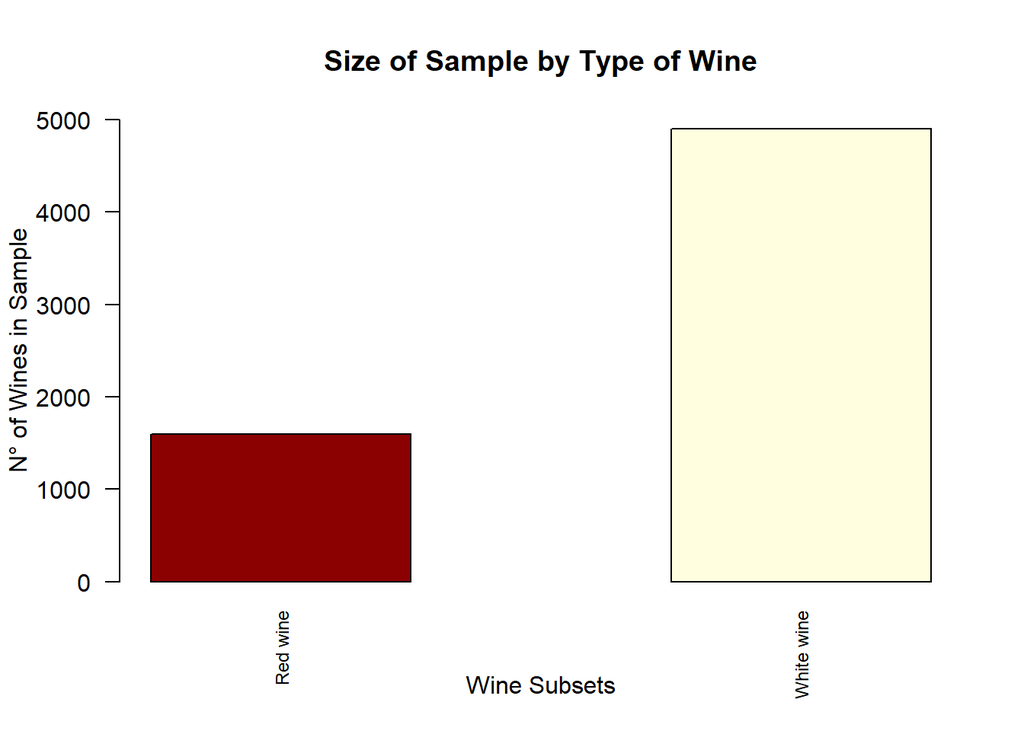

```r
barplot(as.numeric(data_per_type), col = c("#8B0000","#FFFFE0"), width = c(50, 50), las=2, space = 1,
        names.arg= c("Red wine", "White wine"), cex.names=0.75,
        main = "Size of Sample by Type of Wine", ylab = "N° of Wines in Sample", xlab = "Wine Subsets",
        ylim = c(0, 5000))
```

Additionally, it was important to understand the distribution of records by ‘quality’:

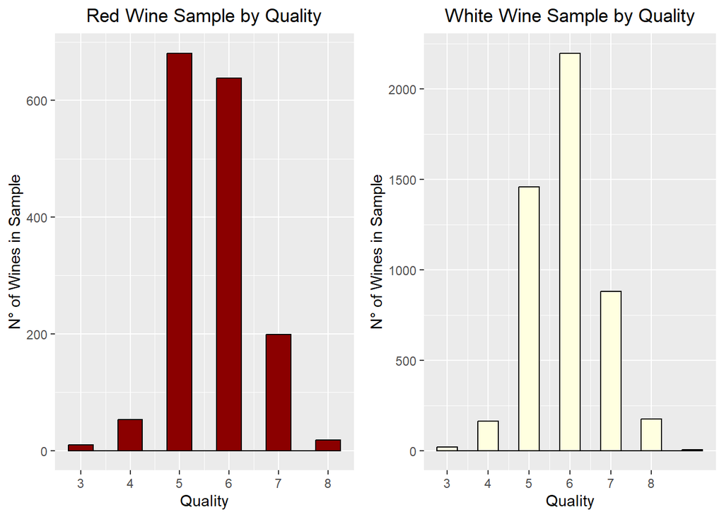

```r
# Red wine plot
rw <-ggplot(aes(x=quality), data =  redw_ds) +
  geom_histogram(color =I('black'),fill = I('#8B0000'), binwidth = 0.5) +
  ggtitle('Red Wine Sample by Quality') +
  xlab('Quality') +
  ylab('N° of Wines in Sample') +
  scale_x_continuous(breaks = unique(redw_ds$quality))+
  theme(plot.title = element_text(hjust = 0.5))

# White wine plot
ww <-ggplot(aes(x=quality), data =  whitew_ds) +
  geom_histogram(color =I('black'),fill = I('#FFFFE0'), binwidth = 0.5) +
  ggtitle('White Wine Sample by Quality') +
  xlab('Quality') +
  ylab('N° of Wines in Sample') +
  scale_x_continuous(breaks = unique(redw_ds$quality))+
  theme(plot.title = element_text(hjust = 0.5))

# Using the arrange option from the grid library
grid.arrange(rw,ww,ncol=2)
```

## Methodology

With both subsets generated, it was crucial to assess the influence of each variable on the ‘quality’. Therefore, a correlation analysis was conducted:

1. All variables from each subset, except the ‘type’ column, were assigned to a new variable **red_var** and **white_var**:

```r
# Red wine
red_var <- setdiff(names(redw_ds), 'type')

# White wine
white_var <- setdiff(names(whitew_ds), 'type')
```

2. A function was created for each ‘type’ to calculate the correlation of the variables with ‘quality’, along with the corresponding p-value (Pearson’s method). This was crucial for understanding whether a correlation existed and determining its statistical significance:

```r
# Red wine
red_cor_func <- function(x) {
  result <- cor.test(x, redw_ds$quality, method = 'pearson')
  return(list(correlation = cor(x, redw_ds$quality), p_value = result$p.value))
}

# White wine
white_cor_func <- function(x) {
  result <- cor.test(x, whitew_ds$quality, method = 'pearson')
  return(list(correlation = cor(x, whitew_ds$quality), p_value = result$p.value))
}
```

3. After that, using lapply(), a list was created containing both results for each ‘type’, which was later transformed into a dataframe:

```r
# Red wine
red_cor_results <- lapply(redw_ds[red_var], red_cor_func)
df_red_cor <- do.call(rbind, red_cor_results)

# White wines
white_cor_results <- lapply(whitew_ds[white_var], white_cor_func)
df_white_cor <- do.call(rbind, white_cor_results)
```

Finally, it is important to keep in mind that if a correlation exists and the test is significant, the correlation coefficient could be a number between -1 and 1:

- Negative correlation (-1 < x < 0): if one variable increases, the other variable in the pair will decrease.
- Positive correlation (0 < x < 1): if one variable increases, the other variable in the pair will also increase.
- Null correlation (x = 0): there is no correlation between the variables in the pair.

## Results

### Red Wine Subset

While analyzing the red wine subset, positive and negative correlations with ‘quality’ were easily determined:

- **Positive correlations:** ‘alcohol’ (0.48), ‘sulphates’ (0.25), ‘citric.acid’ (0.23) and ‘fixed.acidity’ (0,12). ‘residual.sugar’ (0.01) shows a low positive correlation.
- **Negative correlations:** ‘volatile.acidity’ (-0.39), ‘total.sulfur.dioxide’ (-0.19), ‘density’ (-0.18) and ‘chlorides’ (-0.13). ‘Free.sulfur.dioxide’ (-0.05) and ‘pH’ (-0.04) exhibit very low negative correlations.

Furthermore, the correlations with ‘residual.sugar’ and ‘pH’ were not statistically significant, as p-value > 0.05.

```r
df_red_cor
```

```
##                      correlation p_value
## fixed.acidity        0.1230633   7.977543e-07
## volatile.acidity     -0.3906043  1.982394e-59
## citric.acid          0.2263725   4.991295e-20
## residual.sugar       0.01373164  0.583218
## chlorides            -0.1289066  2.313383e-07
## free.sulfur.dioxide  -0.05065606 0.04283398
## total.sulfur.dioxide -0.1851003  8.621703e-14
## density              -0.1749192  1.874957e-12
## pH                   -0.04185755 0.09428732
## sulphates            0.2528018   9.797474e-25
## alcohol              0.4761663   2.831477e-91
## quality              1           0
```

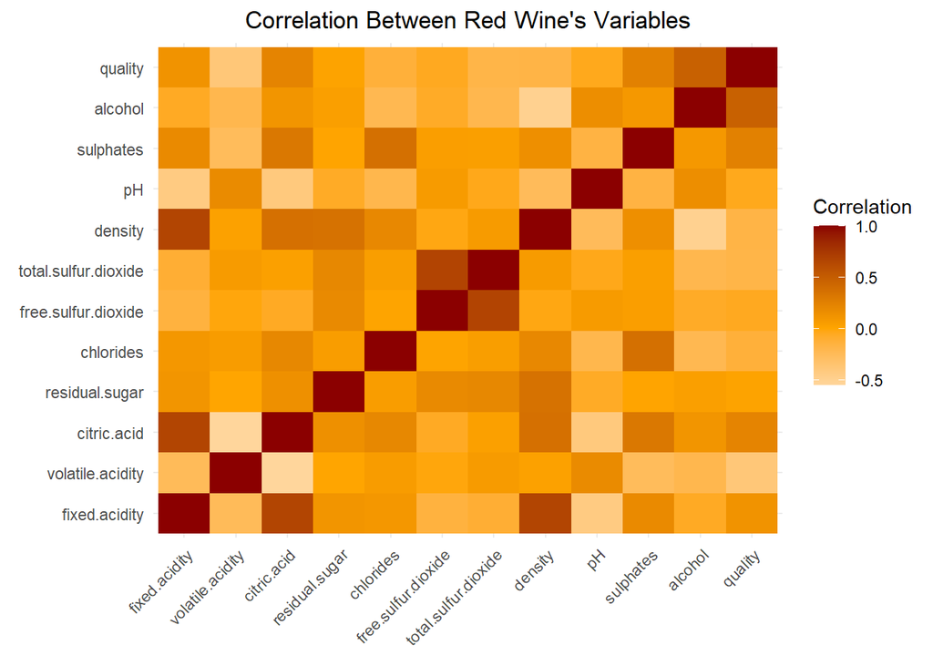

```r
# Create a matrix with the correlations to create a heatmap:

red_cor <- cor(redw_ds[, c("fixed.acidity", "volatile.acidity", "citric.acid", "residual.sugar",
                              "chlorides", "free.sulfur.dioxide", "total.sulfur.dioxide",
                              "density", "pH", "sulphates", "alcohol", "quality")])

melted_red_cor <- melt(red_cor) # this is a function to create the matrix into a dataframe for the heatmap


rw_heatmap <- ggplot(melted_red_cor, aes(x = Var1, y = Var2, fill = value)) +
  geom_tile() +
  scale_fill_gradient2(low = "white", mid = "orange", high = "#8B0000", midpoint = 0) +
  labs(title = "Correlation Between Red Wine's Variables",
       x = element_blank(),
       y = element_blank(),
       fill = "Correlation") +
  theme_minimal() +
  theme(axis.text.x = element_text(angle = 45, hjust = 1),
        plot.title = element_text(hjust = 0.5))

rw_heatmap
```

Taking into account the initial hypothesis and the correlation between ‘quality’ and both ‘fixed.acidity’ and ‘citric.acid’, a line plot was created to visualize these variables based on ‘quality’ levels:

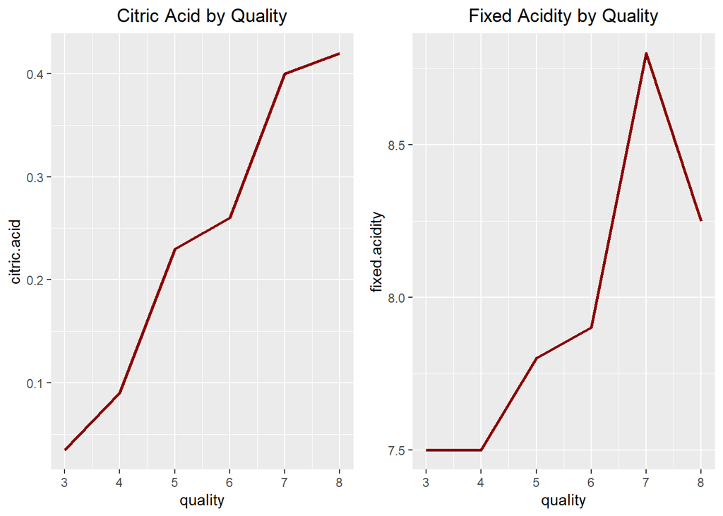

```r
red_citric_acid <- ggplot(aes(x=quality,y=citric.acid),
                      data = redw_ds)+
  stat_summary(geom = "line", fun = "median", aes(group = 1), color = "#8B0000", size = 1)+
  ggtitle('Citric Acid by Quality')+
  theme(plot.title = element_text(hjust = 0.5))

red_fixed_acidity <- ggplot(aes(x=quality,y=fixed.acidity),
                      data = redw_ds)+
  stat_summary(geom = "line", fun = "median", aes(group = 1), color = "#8B0000", size = 1)+
  ggtitle('Fixed Acidity by Quality')+
  theme(plot.title = element_text(hjust = 0.5))

grid.arrange(red_citric_acid, red_fixed_acidity,ncol=2)
```

### White Wine Subset

On the other hand, while examining the subset of white wine, the following correlations with quality were observed:

- **Positive correlations:** ‘alcohol’ (0.44). Additionally, ‘sulphates’ (0.05), ‘pH’ (0.07), and ‘free.sulfur.dioxide’ (0.01) show a low positive correlation.
- **Negative correlations:** ‘density’ (-0.31), ‘chlorides’ (-0.21), ‘volatile.acidity’ (-0.19), ‘total.sulfur.dioxide’ (-0.18), ‘fixed.acidity’ (-0.11) and ‘residual.sugar’ (-0.10). In the case of ‘citric.acid’ (-0.01), the negative correlation is the lowest.

Furthermore, the correlation with ‘citric.acid’ and ‘free.sulfur.dioxide’ were not statistically significant, as p-value > 0.05.

```r
df_white_cor
```

```
##                      correlation  p_value
## fixed.acidity        -0.1064099   8.237126e-14
## volatile.acidity     -0.1943611   6.698839e-43
## citric.acid          -0.008697581 0.5428144
## residual.sugar       -0.09768657  7.317661e-12
## chlorides            -0.2090488   1.689445e-49
## free.sulfur.dioxide  0.008158067  0.5681271
## total.sulfur.dioxide -0.1747372   6.991898e-35
## density              -0.3071233   1.727988e-107
## pH                   0.07396751   2.18993e-07
## sulphates            0.0542291    0.0001464062
## alcohol              0.4355747    5.61477e-226
## quality              1            0
```

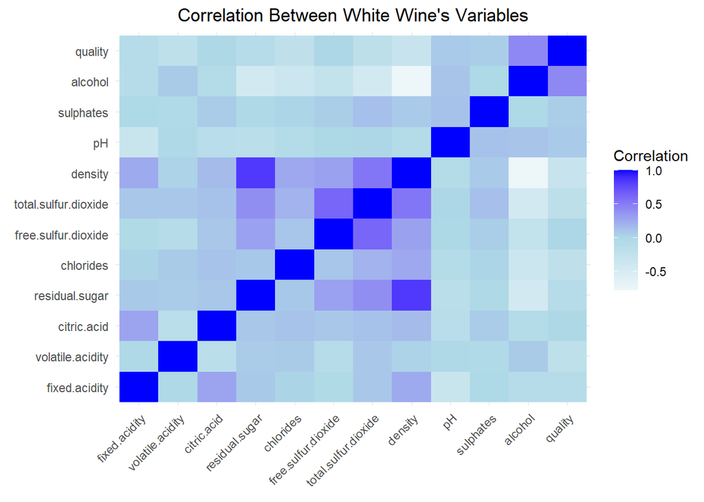

```r
# Create a matrix with the correlations to create a heatmap:

white_cor <- cor(whitew_ds[, c("fixed.acidity", "volatile.acidity", "citric.acid", "residual.sugar",
                               "chlorides", "free.sulfur.dioxide", "total.sulfur.dioxide",
                               "density", "pH", "sulphates", "alcohol", "quality")])

melted_white_cor <- melt(white_cor) # this is a function to create the matrix into a dataframe for the heatmap

ww_heatmap <- ggplot(melted_white_cor, aes(x = Var1, y = Var2, fill = value)) +
  geom_tile() +
  scale_fill_gradient2(low = "white", mid = "lightblue", high = "blue", midpoint = 0) +
  labs(title = "Correlation Between White Wine's Variables",
       x = element_blank(),
       y = element_blank(),
       fill = "Correlation") +
  theme_minimal() +
  theme(axis.text.x = element_text(angle = 45, hjust = 1),
        plot.title = element_text(hjust = 0.5))

ww_heatmap
```

In this case, considering the initial hypothesis and the correlation between ‘quality’ and both ‘residual.sugar’ and acidity, a line plot was created to understand these variables by ‘quality’ level. Since the correlation with ‘citric.acid’ is not statistically significant, ‘pH’ was used as it is an important variable related to acidity *(Cientisol, 2023; Enate, 2022)* and, in this case, if both were correlated and statistically significant.

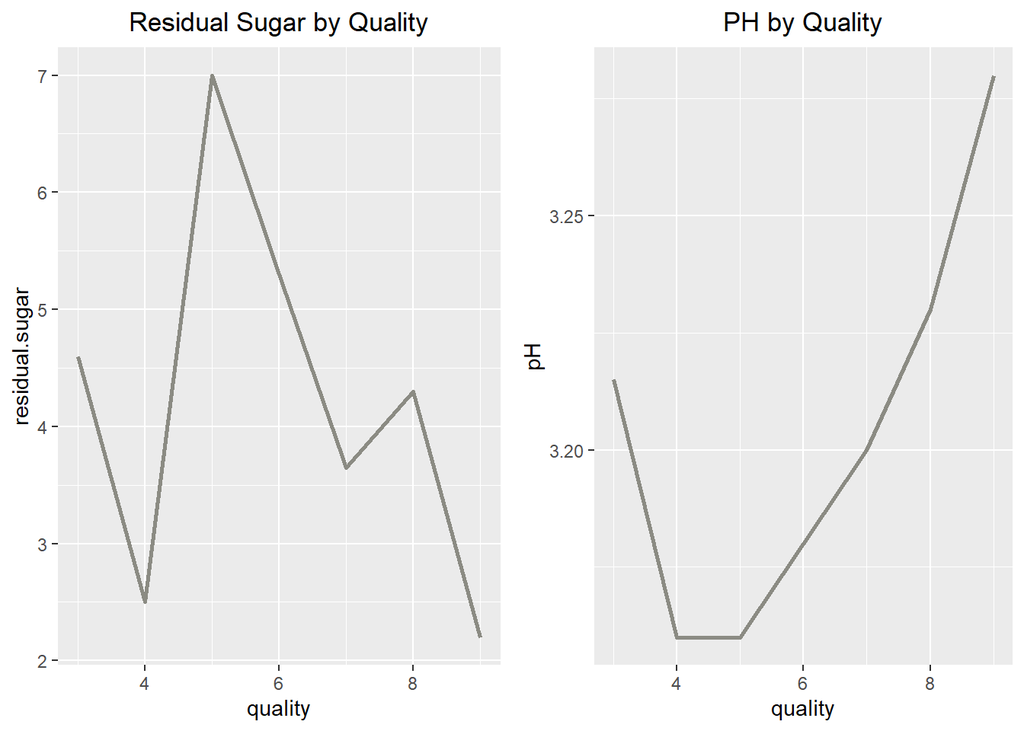

```r
white_sugar <- ggplot(aes(x = quality,y=residual.sugar),
                          data = whitew_ds)+
  stat_summary(geom = "line", fun = "median", aes(group = 1), color = "#8B8B83", size = 1)+
  ggtitle('Residual Sugar by Quality')+
  theme(plot.title = element_text(hjust = 0.5))

white_pH <- ggplot(aes(x = quality,y=pH),
                          data = whitew_ds)+
  stat_summary(geom = "line", fun = "median", aes(group = 1), color = "#8B8B83", size = 1)+
  ggtitle('PH by Quality')+
  theme(plot.title = element_text(hjust = 0.5))

grid.arrange(white_sugar,white_pH,ncol=2)
```

### Complementary Results

In addition to the primary results, it was important to understand the ‘pH’ distribution for each ‘type’ of wine, as it is a crucial indicator for wine production *(Cientisol, 2023; Enate, 2022)*.

```r
ph_stats <- wine2_ds %>%
  group_by(type) %>%
  summarize(
    min = min(pH[pH != 0]),
    mean = mean(pH),
    median = median(pH),
    max = max(pH),
    sd = sd(pH),
    )
ph_stats
```

```
## # A tibble: 2 × 6
##   type    min  mean median   max    sd
##   <chr> <dbl> <dbl>  <dbl> <dbl> <dbl>
## 1 red    2.74  3.31   3.31  4.01 0.194
## 2 white  2.72  3.18   3.18  3.82 0.193
```

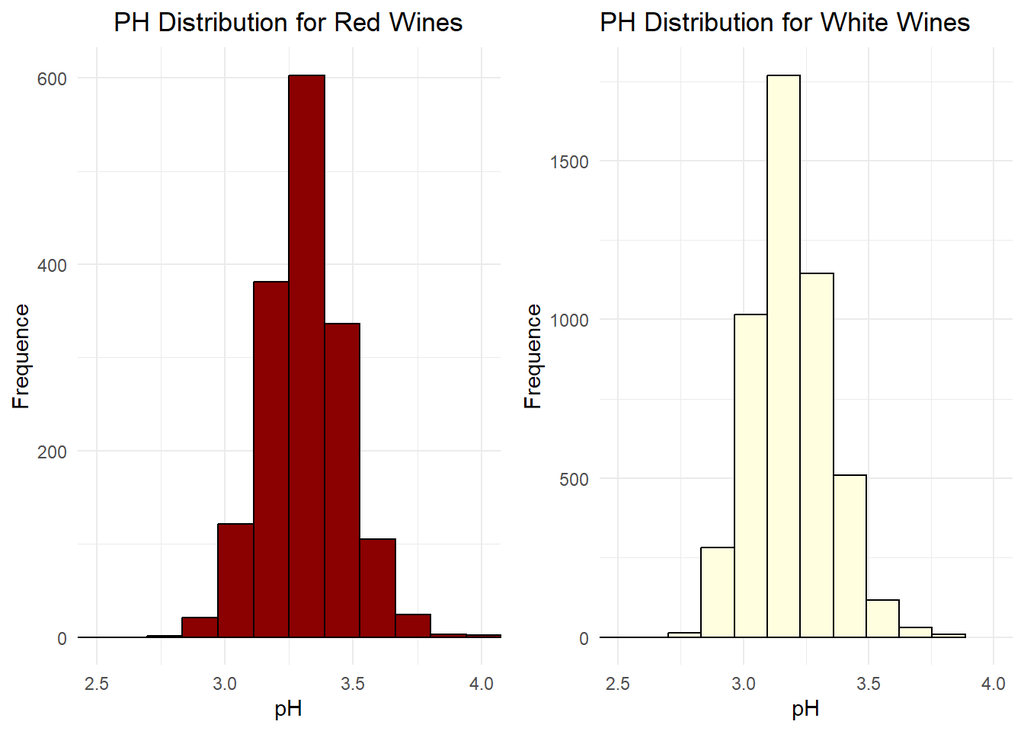

```r
red_ph <- ggplot(aes(x=pH),
                      data = redw_ds)+
  geom_histogram(color =I('black'),fill = I('#8B0000'))+
  ggtitle('PH Distribution for Red Wines')+
  xlab('pH') +
  ylab('Frequence') +
  theme_minimal() +
  coord_cartesian(xlim = c(2.5, 4))+
  theme(plot.title = element_text(hjust = 0.5))

ww_ph <- ggplot(aes(x=pH),
                data = whitew_ds)+
  geom_histogram(color =I('black'),fill = I('#FFFFE0'))+
  ggtitle('PH Distribution for White Wines')+
  xlab('pH') +
  ylab('Frequence') +
  theme_minimal() +
  coord_cartesian(xlim = c(2.5, 4))

grid.arrange(red_ph,ww_ph,ncol=2)
```

With a normal distribution, the ‘pH’ levels in both wine types fall within the typical range of 2.8 – 4 *(Cientisol, 2023; Enate, 2022)*. Moreover, according to the tibble created, there is a clear distinction between both ‘types’, with red wine averaging around a ‘pH’ of 3.31, while whites are closer to an average of 3.18. Regarding the standard deviation, it indicates that much of the observed data is tightly clustered around the mean, suggesting that, in general, red and white wines tend to have these ‘pH’ levels.

In addition to the wine’s ‘pH’, there is an important negative correlation between ‘alcohol’ and ‘residual.sugar’. This is attributed to the fermentation process, which increases the ‘alcohol’ level by utilizing the glucose present in the production.

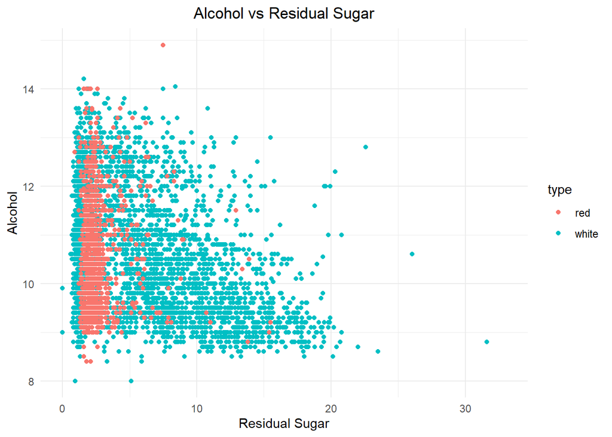

```r
alcohol_sugar <- ggplot(wine2_ds, aes(x = residual.sugar, y = alcohol, color = type)) +
  geom_point() +
  ggtitle('Alcohol vs Residual Sugar') +
  xlab('Residual Sugar') +
  ylab('Alcohol') +
  theme_minimal()+
  coord_cartesian(xlim = c(0, 33))+
  theme(plot.title = element_text(hjust = 0.5))

alcohol_sugar
```

Finally, an analysis regarding ‘sulphates’, ‘chlorides’, and ‘sulfur.dioxide’ is essential, as these variables play a crucial role in wine preservation, facilitating the production of wines less prone to oxidation. This, in turn, enhances organoleptic properties, emphasizing flavor, color, and aroma *(Pardal, 2014; Serres, n.d.; Vinetur, 2015)*.

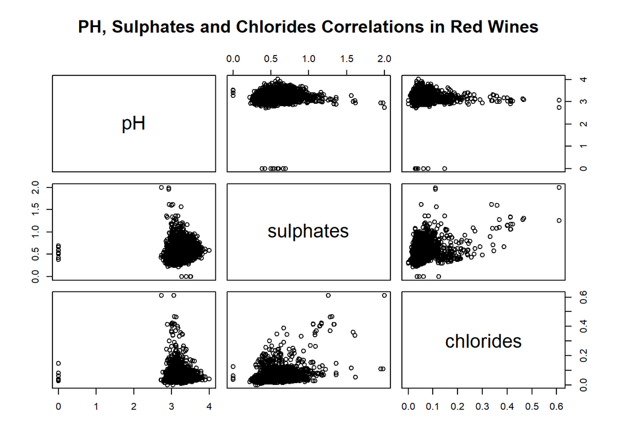

```r
red_csp_corr <- pairs(~pH + sulphates + chlorides, data = wine2_ds,
                     main = 'PH, Sulphates and Chlorides Correlations in Red Wines')
```

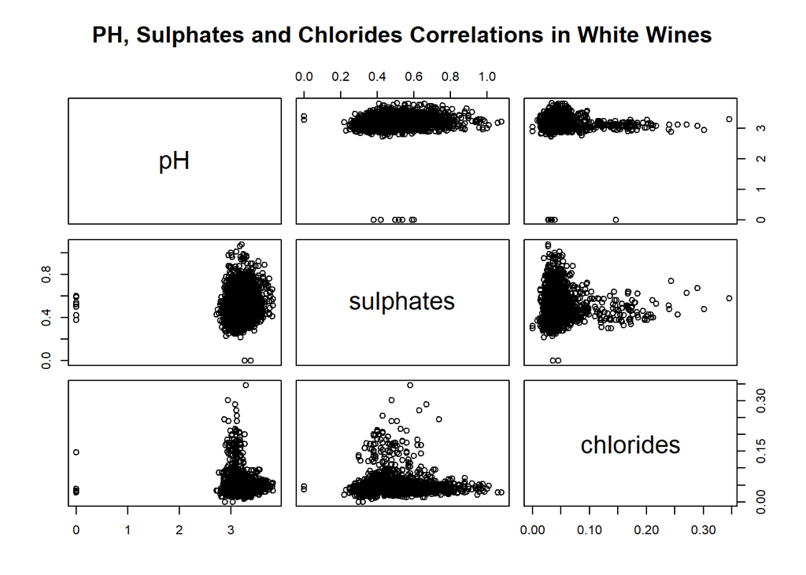

```r
white_csp_corr <- pairs(~pH + sulphates + chlorides, data = whitew_ds,
                      main = 'PH, Sulphates and Chlorides Correlations in White Wines')
```

- **Correlation between ‘total.sulfur.dioxide’ and ‘free.sulfur.dioxide’**: There is a clear positive correlation between both variables since ‘free.sulfur.dioxide’ is part of ‘total.sulfur.dioxide.’ It’s important to note the distinction between red and white wines, with white wines containing higher levels of sulfur dioxide.

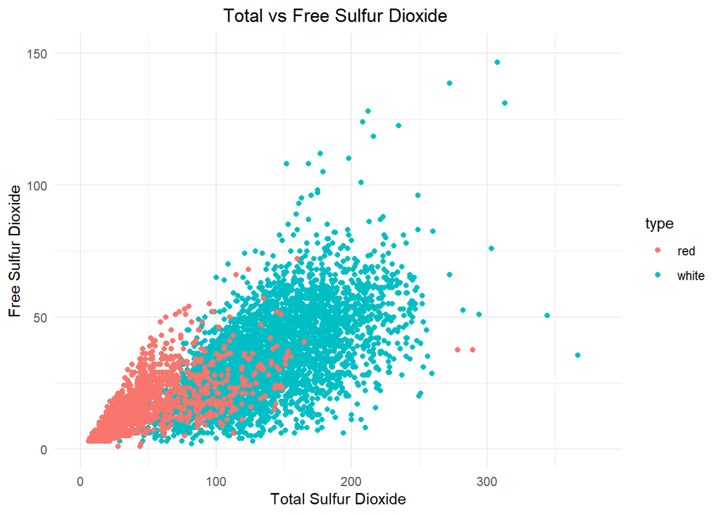

```r
ggplot(wine2_ds, aes(x = total.sulfur.dioxide, y = free.sulfur.dioxide, color = type)) +
  geom_point() +
  ggtitle('Total vs Free Sulfur Dioxide ') +
  xlab('Total Sulfur Dioxide') +
  ylab('Free Sulfur Dioxide') +
  theme_minimal()+
  coord_cartesian(xlim = c(0, 380), ylim = c(0, 150))+
  theme(plot.title = element_text(hjust = 0.5))
```

## Conclusion

In conclusion, based on the results obtained in this project, it can be asserted that red wines exhibit higher ‘quality’ levels when acidity (‘citric.acid’ and ‘fixed.acidity’) is higher. Conversely, white wines tend to have higher ‘quality’ levels when ‘pH’ is higher (indicating lower acidity) and ‘residual.sugar’ is lower. Therefore, **it can be concluded that the initially hypothesized correlation was not entirely supported**. Further analysis is recommended, particularly regarding the relationship between acidity and ‘quality’ in both cases, and ‘residual.sugar’ with’ ‘quality’ in white wines.

Last but not least, it is important to highlight the need of further analysis in the wine properties and quality. Some ideas highly recommended are:

- **Enrich the dataset**: Expand the dataset by including more information (mainly red wines that have fewer records) such as grape origin, types of grapes, maturation, and other relevant details. This additional information can provide a more comprehensive understanding of the factors influencing wine properties and quality.
- **Deepen in the analysis of acidity in red wines**: While the project suggests a positive correlation between higher acidity levels and better quality in red wines, it is essential to delve deeper into whether increased acidity genuinely enhances quality or if these variables serve other roles in the production process. This entails conducting further analysis to explore their correlations with other variables.
- **Explore other correlations**: Extend the analysis to examine correlations among variables beyond quality. Each variable likely plays a crucial role in the wine production process, and understanding these relationships can offer valuable insights.
- **White wine types** *(Domecq, 2023)*: Differentiate white wine records based on their sweetness levels, categorizing them as sweet, demi-sec, or dry (sec). This distinction will contribute to a more nuanced analysis, allowing for a better determination of the impact of sweetness on the quality of white wines.

## References

[1]. Cientisol. (2023). Guía definitiva sobre el análisis químico del vino: Qué parámetros hay que medir y cómo hacerlo. https://cientisol.com/guia-definitiva-sobre-el-analisis-quimico-del-vino-que-parametros-hay-que-medir-y-como-hacerlo/.

[2]. Domecq, B. M. (2023). Tipos de vino blanco según su contenido en azúcar. https://migueldomecq.com/tipos-de-vino-blanco-segun-su-azucar/.

[3]. Enate. (2022). ¿Qué es el pH en el vino? https://www.enate.es/blog/que-es-el-ph-en-el-vino/.

[4]. Kaggle. (2018). Wine quality. https://www.kaggle.com/datasets/rajyellow46/wine-quality/.

[5]. Pardal, C. N. (2014). Libreta del enólogo: Los sulfatos. https://www.viladellops.com/es/libreta-del-enologo-los-sulfatos/.

[6]. Rioja, E. C. de. (n.d.). EL SABOR ÁCIDO EN EL VINO. https://www.elcoto.com/blog/sabor-acido-vino/.

[7]. Sanchoyarto, R. (n.d.). Ácidos y acidez en el vino. https://www.aprenderdevino.es/acidos-acidez-vino/.

[8]. Serres, C. (n.d.). El dióxido de azufre y su función en los vinos. https://carlosserres.com/dioxido-azufre-funcion-vino/.

[9]. Vinetur. (2015). ¿Cuánta sal tiene el vino? https://www.vinetur.com/2015050419254/cuanta-sal-tiene-el-vino.html.

[10]. Viudas, S. (2022). ¿QUÉ ES LA ACIDEZ EN EL VINO? https://seguraviudas.com/es/noticias/vinos-y-cavas/acidez-vino/.